# Assessment_1-Arham_Lodha

#### Aim : To assist Client X to improve their motor portfolio performance

#### Client X is a mid-sized insurer in Asian market where motor is the main line of business.

### EDA

#### Importing Dataset and Libraries

```python
from zipfile import ZipFile
import pandas as pd
import numpy as np
import matplotlib.pyplot as plt
import seaborn as sns
import warnings
warnings.filterwarnings("ignore")
pd.set_option('display.max_columns', None)
from scipy import stats



file_name = "for_assessment_1.zip"
with ZipFile(file_name, 'r') as zip:
    zip.printdir()
    zip.extractall()
customer = pd.read_csv('Dataset_assessment1/customer.csv')
hist_claims = pd.read_csv('Dataset_assessment1/historical_claims.csv')
policies = pd.read_csv('Dataset_assessment1/policies.csv')
```

```
File Name                                             Modified             Size
Dataset_assessment1/customer.csv               2022-09-27 16:14:24     40282473
Dataset_assessment1/historical_claims.csv      2022-09-27 16:14:28    202522640
Dataset_assessment1/policies.csv               2022-09-27 16:14:24    545122098
```

# Customer Dataset

- Exploring Client X's Customers

```python
customer
```

|  | CUSTOMER_IDENTIFIER | GENDER | DRIVING_EXPERIENCE |
| --- | --- | --- | --- |
| 0 | CUSTOMER_1 | M | THREE_TO_FIVE_YEARS |
| 1 | CUSTOMER_2 | M | THREE_TO_FIVE_YEARS |
| 2 | CUSTOMER_3 | M | THREE_TO_FIVE_YEARS |
| 3 | CUSTOMER_4 | F | THREE_TO_FIVE_YEARS |
| 4 | CUSTOMER_5 | F | THREE_TO_FIVE_YEARS |
| ... | ... | ... | ... |
| 1038555 | CUSTOMER_1038556 | M | THREE_TO_FIVE_YEARS |
| 1038556 | CUSTOMER_1038557 | F | THREE_TO_FIVE_YEARS |
| 1038557 | CUSTOMER_1038558 | M | THREE_TO_FIVE_YEARS |
| 1038558 | CUSTOMER_1038559 | M | THREE_TO_FIVE_YEARS |
| 1038559 | CUSTOMER_1038560 | M | THREE_TO_FIVE_YEARS |

1038560 rows × 3 columns

```python
customer.info()
```

```
<class 'pandas.core.frame.DataFrame'>
RangeIndex: 1038560 entries, 0 to 1038559
Data columns (total 3 columns):
 #   Column               Non-Null Count    Dtype
---  ------               --------------    -----
 0   CUSTOMER_IDENTIFIER  1038560 non-null  object
 1   GENDER               1038560 non-null  object
 2   DRIVING_EXPERIENCE   1038560 non-null  object
dtypes: object(3)
memory usage: 23.8+ MB
```

#### Conclusion :No Null Values were observed in the Customer Dataset

```python
print('Customers served till date by Client X :', len(customer['CUSTOMER_IDENTIFIER'].unique()))
```

```
Customers served till date by Client X : 1038560
```

#### Aim : Find the Male : Female Ratio

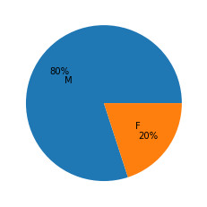

```python
counter = customer['GENDER'].value_counts().values
gender = customer['GENDER'].value_counts().index
plt.pie(counter,labels=gender,autopct='%1.0f%%', pctdistance=0.7, labeldistance=0.5)
plt.show()
```

#### Conclusion: As per the customer data , Male : Female ratio is 4:1

#### Aim : Driving Experience Mix of the customers

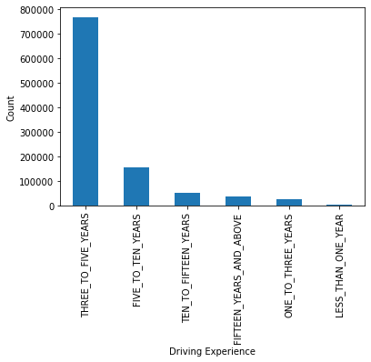

```python
customer['DRIVING_EXPERIENCE'].value_counts().plot(kind='bar')
plt.xlabel('Driving Experience')
plt.ylabel('Count')
```

#### Conclusion: Client X has majority of their customers who have Three to Five Years of Driving Experience

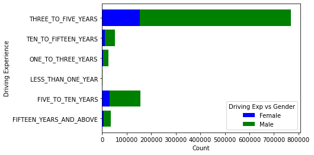

```python
gender_vs_exp = pd.crosstab(customer['DRIVING_EXPERIENCE'] , customer['GENDER'])
b1 = plt.barh(gender_vs_exp.index, gender_vs_exp['F'], color="blue")
b2 = plt.barh(gender_vs_exp.index, gender_vs_exp['M'],left=gender_vs_exp['F'] ,color="green")
plt.legend([b1, b2], ["Female", "Male"], title="Driving Exp vs Gender", loc="lower right")
plt.ylabel('Driving Experience')
plt.xlabel('Count')
```

# Policies Dataset

- Exploring Policies written by Client X

```python
policies.head()
```

|  | POLICY_WRITTEN_BRANCH | POLICY_IDENTIFIER | PREVIOUS_INSURER_NAME | POLICY_START_DATE | POLICY_END_DATE | CANCELLATION_DATE | SUM_INSURED | GWP | COMPULSORY_DEDUCTABLE | PRODUCT | PRODUCT_CODE | VEHICLE_IDENTIFIER |
| --- | --- | --- | --- | --- | --- | --- | --- | --- | --- | --- | --- | --- |
| 0 | BRANCH_104 | POLICY_2981310 | MAIN_INSURANCE | 2014-05-05 | 2015-05-04 | 2015-05-04 | 7.800000e+06 | 69911 | 2000 | COMMERCIAL MOTOR MISCELLANEOUS VEHICLES | product_ 3 | VEHICLE_770218 |
| 1 | BRANCH_104 | POLICY_2746285 | MAIN_INSURANCE | 2016-05-06 | 2017-05-05 | NaN | 2.268196e+11 | 51831 | 2000 | PRIVATE MOTOR 3 & 4 WHEELER | product_ 1 | VEHICLE_862671 |
| 2 | BRANCH_104 | POLICY_2052928 | Others_ 23 | 2013-01-22 | 2014-01-21 | NaN | 3.800000e+05 | 2654 | 1000 | PRIVATE MOTOR 2 WHEELER | product_ 2 | VEHICLE_139789 |
| 3 | BRANCH_104 | POLICY_2507456 | MAIN_INSURANCE | 2015-07-21 | 2016-07-19 | NaN | 4.940000e+06 | 24377 | 0 | PRIVATE MOTOR 3 & 4 WHEELER | product_ 1 | VEHICLE_1606551 |
| 4 | BRANCH_104 | POLICY_2950161 | MAIN_INSURANCE | 2016-01-06 | 2017-01-04 | 2017-01-02 | 4.480000e+06 | 27824 | 1000 | LONG TERM TWO WHEELER PACKAGE | product_ 7 | VEHICLE_942145 |

```python
print('Policies written till date by Client X :', len(policies['POLICY_IDENTIFIER'].unique()))
```

```
Policies written till date by Client X : 3430000
```

```python
policies.info()
```

```
<class 'pandas.core.frame.DataFrame'>
RangeIndex: 3430000 entries, 0 to 3429999
Data columns (total 12 columns):
 #   Column                 Dtype
---  ------                 -----
 0   POLICY_WRITTEN_BRANCH  object
 1   POLICY_IDENTIFIER      object
 2   PREVIOUS_INSURER_NAME  object
 3   POLICY_START_DATE      object
 4   POLICY_END_DATE        object
 5   CANCELLATION_DATE      object
 6   SUM_INSURED            float64
 7   GWP                    int64
 8   COMPULSORY_DEDUCTABLE  int64
 9   PRODUCT                object
 10  PRODUCT_CODE           object
 11  VEHICLE_IDENTIFIER     object
dtypes: float64(1), int64(2), object(9)
memory usage: 314.0+ MB
```

#### Aim: To find Correlation between continous variables

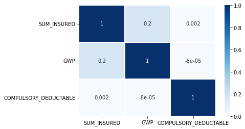

```python
plt.figure()
sns.heatmap(policies.corr(),cmap='Blues', fmt='.1g',linewidths=0.30,annot=True)
plt.show()
```

#### Conclusion : Weak Positive Correlation observed between GWP and Sum Insured

#### Converting Date Columns from object to Datetime Format

```python
policies['CANCELLATION_DATE'] = pd.to_datetime(policies['CANCELLATION_DATE'])
policies['POLICY_END_DATE'] = pd.to_datetime(policies['POLICY_END_DATE'])
policies['POLICY_START_DATE'] = pd.to_datetime(policies['POLICY_START_DATE'])
```

```python
len(policies['VEHICLE_IDENTIFIER'].unique())
```

```
1446648
```

#### Aim : Why are policies written more than the number of vehicles ?

```python
X=policies[policies['VEHICLE_IDENTIFIER'].duplicated()].sort_values(by='VEHICLE_IDENTIFIER')
X[X['VEHICLE_IDENTIFIER'] =='VEHICLE_10']
```

|  | POLICY_WRITTEN_BRANCH | POLICY_IDENTIFIER | PREVIOUS_INSURER_NAME | POLICY_START_DATE | POLICY_END_DATE | CANCELLATION_DATE | SUM_INSURED | GWP | COMPULSORY_DEDUCTABLE | PRODUCT | PRODUCT_CODE | VEHICLE_IDENTIFIER |
| --- | --- | --- | --- | --- | --- | --- | --- | --- | --- | --- | --- | --- |
| 638325 | BRANCH_39 | POLICY_2958529 | MAIN_INSURANCE | 2014-09-09 | 2015-09-08 | 2015-07-13 | 6100000.0 | 72414 | 2000 | COMMERCIAL MOTOR MISCELLANEOUS VEHICLES | product_ 3 | VEHICLE_10 |
| 2266135 | BRANCH_67 | POLICY_1367552 | Others_ 17 | 2015-12-15 | 2016-12-13 | NaT | 650000.0 | 6484 | 1000 | LONG TERM TWO WHEELER PACKAGE | product_ 7 | VEHICLE_10 |
| 2266693 | BRANCH_67 | POLICY_637552 | MAIN_INSURANCE | 2016-12-15 | 2017-12-14 | 2017-11-24 | 340000.0 | 3129 | 1000 | LONG TERM TWO WHEELER PACKAGE | product_ 7 | VEHICLE_10 |

#### Conlusion :Number of Unique Vehicles is less than the number of Total Policies Written .Implies that multiple policies have been written over the lifetime of a Vehicle. Moreover, Motor Insurance Plans are valid for a period of 364 days , explains the continuous renewal of policies.

```python
print(max(policies['POLICY_END_DATE'] - policies['POLICY_START_DATE']))
print(min(policies['POLICY_END_DATE'] - policies['POLICY_START_DATE']))
```

```
364 days 00:00:00
364 days 00:00:00
```

#### Irrespective of the Product Type , Client X has written policies for a total duration of 364 days

```python
policies.isnull().sum()
```

```
POLICY_WRITTEN_BRANCH          0
POLICY_IDENTIFIER              0
PREVIOUS_INSURER_NAME          0
POLICY_START_DATE              0
POLICY_END_DATE                0
CANCELLATION_DATE        1780000
SUM_INSURED                    0
GWP                            0
COMPULSORY_DEDUCTABLE          0
PRODUCT                        0
PRODUCT_CODE                   0
VEHICLE_IDENTIFIER             0
dtype: int64
```

#### Aim : Why are some values null corresponding to our Cancellation_Date attribute .

#### Assumption :

#### Cancellation Date for a policy can be associated with Two Scenarios

- Scenario A : Policy allowed to expire ( Cancellation Date == Policy End Date == Auto Cancelled == Null Values)
- Scenario B : Policy cancelled by Client X or by the insured person

```python
print('Scenario A : Policies allowed to expire:', policies['CANCELLATION_DATE'].isnull().sum() + len(policies[policies['CANCELLATION_DATE'] == policies['POLICY_END_DATE']]))
```

```
Scenario A : Policies allowed to expire: 2770800
```

```python
filter1 = policies['CANCELLATION_DATE']< policies['POLICY_END_DATE']
filter2 = policies['CANCELLATION_DATE']> policies['POLICY_START_DATE']
policies.where(filter1 & filter2).dropna().head(3)
```

|  | POLICY_WRITTEN_BRANCH | POLICY_IDENTIFIER | PREVIOUS_INSURER_NAME | POLICY_START_DATE | POLICY_END_DATE | CANCELLATION_DATE | SUM_INSURED | GWP | COMPULSORY_DEDUCTABLE | PRODUCT | PRODUCT_CODE | VEHICLE_IDENTIFIER |
| --- | --- | --- | --- | --- | --- | --- | --- | --- | --- | --- | --- | --- |
| 4 | BRANCH_104 | POLICY_2950161 | MAIN_INSURANCE | 2016-01-06 | 2017-01-04 | 2017-01-02 | 4480000.0 | 27824.0 | 1000.0 | LONG TERM TWO WHEELER PACKAGE | product_ 7 | VEHICLE_942145 |
| 5 | BRANCH_104 | POLICY_2904539 | MAIN_INSURANCE | 2015-07-03 | 2016-07-01 | 2016-03-19 | 2900000.0 | 52763.0 | 1000.0 | COMMERCIAL MOTOR PASSENGER CARRYING | product_ 5 | VEHICLE_33358 |
| 11 | BRANCH_104 | POLICY_193545 | MAIN_INSURANCE | 2013-06-09 | 2014-06-08 | 2014-03-13 | 380000.0 | 1545.0 | 2000.0 | PRIVATE MOTOR 3 & 4 WHEELER | product_ 1 | VEHICLE_503412 |

```python
print('Scenario B : Policies Cancelled before Policy End Date:', len(policies.where(filter1 & filter2).dropna()))
```

```
Scenario B : Policies Cancelled before Policy End Date: 659200
```

#### Conclusion : There are 659200 instances where policies have been cancelled before the Policy End Date.Client X should try and understand the reason behind the drop off in customers.

Unsatisfactory Service ? Theft of Vehicle ? Change of Vehicle ?

#### Null Values of Cancellation Dates could be filled with Policy End Date keeping Scenario A in mind

```python
policies['CANCELLATION_DATE_NEW'] = policies['CANCELLATION_DATE']
```

```python
policies['CANCELLATION_DATE_NEW'] = policies['CANCELLATION_DATE_NEW'].fillna(policies['POLICY_END_DATE'])
```

```python
policy_tenure = policies['CANCELLATION_DATE_NEW'] - policies['POLICY_START_DATE']
print(policy_tenure.value_counts().idxmin() ,'is the minimum period that a policy lasted before cancellation')
print(policy_tenure.value_counts().max(), 'policies were not cancelled and were only cancelled (Auto Cancelled) after a period of',policy_tenure.value_counts().idxmax())
```

```
277 days 00:00:00 is the minimum period that a policy lasted before cancellation
2770800 policies were not cancelled and were only cancelled (Auto Cancelled) after a period of 364 days 00:00:00
```

#### Aim : Find the number of policies written per branch

```python
policiesbybranch = policies.groupby('POLICY_WRITTEN_BRANCH').agg({'POLICY_IDENTIFIER':'count'})
policiesbybranch = policiesbybranch.sort_values(by='POLICY_IDENTIFIER',ascending=False).rename(columns={'POLICY_IDENTIFIER':'TotalPolicies'})
policiesbybranch.head()
```

| POLICY_WRITTEN_BRANCH | TotalPolicies |
| --- | --- |
| BRANCH_34 | 140160 |
| BRANCH_45 | 111145 |
| BRANCH_4 | 107928 |
| BRANCH_1 | 87604 |
| BRANCH_14 | 86589 |

```python
policiesbybranch.iloc[0,:] / policiesbybranch.iloc[1,:]
```

```
TotalPolicies    1.261055
dtype: float64
```

#### Conclusion : Client X has 123 Branches where policies are written.

- Branch 34 has written the most number of policies while Branch 122, 123 have writtten the least number of policies.

#### Branch 34 has written 1.3X the policies written by Branch 45.

### Feature Engineering for Policies Dataset

#### Aim : Perform Feature Engineering to create a new column Cancellation Rate

```python
filter1 = policies['CANCELLATION_DATE']< policies['POLICY_END_DATE']
filter2 = policies['CANCELLATION_DATE']> policies['POLICY_START_DATE']
cancelled_policies_by_branch = policies.where(filter1 & filter2).dropna()['POLICY_WRITTEN_BRANCH'].value_counts().to_frame().rename(columns={'POLICY_WRITTEN_BRANCH':'Total_Cancelled_Policies'})
policies_written_by_branch = policies['POLICY_WRITTEN_BRANCH'].value_counts().to_frame().rename(columns={'POLICY_WRITTEN_BRANCH':'Total_Policies_Written'})
```

```python
Cancellation_Table = pd.merge(cancelled_policies_by_branch,policies_written_by_branch,left_index=True,right_index=True)
Cancellation_Table['Cancellation_Rate'] = Cancellation_Table['Total_Cancelled_Policies'] /Cancellation_Table['Total_Policies_Written']
```

```python
Cancellation_Table.sort_values(by='Cancellation_Rate',ascending=False).head()
```

|  | Total_Cancelled_Policies | Total_Policies_Written | Cancellation_Rate |
| --- | --- | --- | --- |
| BRANCH_123 | 2 | 8 | 0.250000 |
| BRANCH_122 | 2 | 8 | 0.250000 |
| BRANCH_120 | 8 | 33 | 0.242424 |
| BRANCH_116 | 58 | 246 | 0.235772 |
| BRANCH_111 | 160 | 764 | 0.209424 |

#### Conclusion : Branch 123 , 122, 120 , 116 are the branches having the highest cancellation rate . At the same time the total number of policies written by these branches are minimal comapred to other branches .

#### We can therefore state that these branches are either new branches that are taking some time to scale and adapt to the situation or they might be operationally inefficient.

#### Aim : Bucketing the Product Varibale to reduce the cardinality and checking for the avg GWP

```python
def set_scr(policies):
    if policies['PRODUCT'] == 'COMMERCIAL MOTOR MISCELLANEOUS VEHICLES':
        return 'Commercial'
    if policies['PRODUCT'] == 'COMMERCIAL MOTOR PASSENGER CARRYING':
        return 'Commercial'
    if policies['PRODUCT'] == 'COMMERCIAL MOTOR GOODS CARRYING':
        return 'Commercial'
    if policies['PRODUCT'] == 'PRIVATE MOTOR 3 & 4 WHEELER':
        return 'Private'
    if policies['PRODUCT'] == 'PRIVATE MOTOR 2 WHEELER':
        return 'Private'
    if policies['PRODUCT'] == 'LONG TERM TWO WHEELER PACKAGE':
        return 'Private'
    else :
        return 'Motor Trade Insurance'
```

```python
policies['Pooled_Products']=policies.apply(set_scr,axis=1)
```

```python
policies['Pooled_Products'].value_counts()
```

```
Private                  1947001
Commercial               1085637
Motor Trade Insurance     397362
Name: Pooled_Products, dtype: int64
```

```python
policies.groupby('Pooled_Products')['GWP'].mean()
```

```
Pooled_Products
Commercial               45735.956592
Motor Trade Insurance    39389.948621
Private                  44449.333654
Name: GWP, dtype: float64
```

#### Conclusion : Client X's avg. GWP is similar irrespective of the usage of the Product . Hence Client can introduce new offerings where GWP for a commercial vehicle is higher than Private Vehicle considering the rigorous usage of the vehicle and more chances of claiming the insurance

#### Aim : Find out previous insurer of the insured

```python
policiesbyprevinsurer = policies.groupby('PREVIOUS_INSURER_NAME').agg({'POLICY_IDENTIFIER':'count'}).transform(lambda x: x/x.sum())
print(policiesbyprevinsurer.idxmax())
print(policiesbyprevinsurer.max())
```

```
POLICY_IDENTIFIER    MAIN_INSURANCE
dtype: object
POLICY_IDENTIFIER    0.695909
dtype: float64
```

#### Conclusion: 69% of the policies were first written by MAIN_INSURANCE .Client X has emerged as a challenger to MAIN_INSURANCE

### Outlier Detection in Policies Dataset

#### Aim : Exploring Sum Insured Variable

```python
policies['SUM_INSURED'].describe().apply(lambda x: '%.0f' % x)
```

```
count         3430000
mean      10286053681
std       57764144215
min            200000
25%            700000
50%           5000000
75%           9500000
max      493775868984
Name: SUM_INSURED, dtype: object
```

#### Conclusion: Some Policies have extremely large Sum Insured Values . There are 2 ways in which we can deal with these Outliers .

- Perform no operation . Try to Justify them with a factual backing . For Example : - Large Sum Insured is for an entire Motor Manufacturing company
- Perform Statistical Test such as z-score , IQR , Quantile Methods to define a critical range of acceptable Sum Insured Amount.

#### Aim : Product Portfolio of Client X

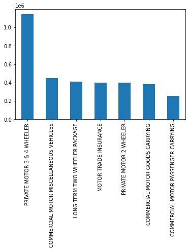

```python
policies['PRODUCT'].value_counts().plot(kind='bar')
```

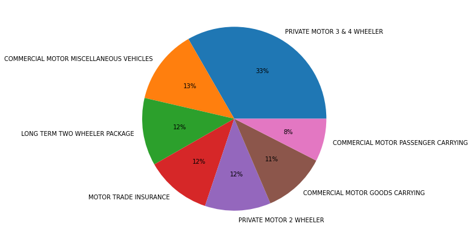

```python
policies['PRODUCT'].value_counts().plot(kind='pie',figsize =(10, 7), autopct='%1.0f%%')
plt.ylabel("")
```

#### Conclusion: Client has a good diversification between 7 different types of Products . Albeit , we can infer from the graph above that the most sold policy by Client X is PRIVATE MOTOR 3 & 4 WHEELER

#### Aim : Product Wise Sum Insured

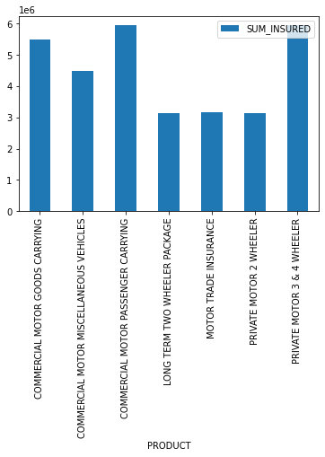

```python
policies.groupby('PRODUCT').agg({'SUM_INSURED':'median'}).plot(kind='bar')
```

#### Aim : Extract the number of policies written every Year

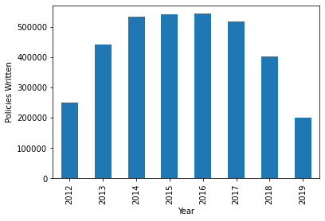

```python
pd.DatetimeIndex(policies['POLICY_START_DATE']).year.value_counts().sort_index().plot(kind='bar')
plt.xlabel('Year')
plt.ylabel('Policies Written')
```

#### Conclusion: Companies operations started in the year 2012. Since then the number of policies written increased progressively. Although after 2016,performance of the company plateaued and eventually number of policies written nosedived

#### Aim : To check for the distribution of GWP variable

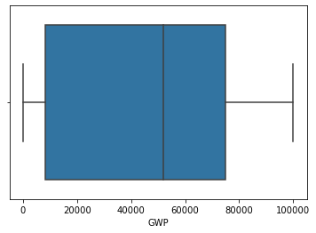

```python
sns.boxplot(policies['GWP'])
```

#### Conclusion: GWP stands for Gross Written Premium. Gross written premiums (GWP) are the total premiums an insurer writes during a specific period.

- Client X has large number of small ticket size premium .
- A deeper analysis into GWP tells us that some of the Premiums to be collected are 0 which is not possible.

#### Aim : To analyse Compulsory Deductable Amount

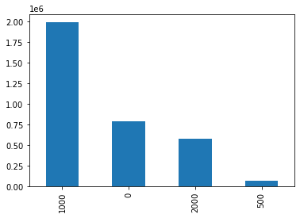

```python
policies['COMPULSORY_DEDUCTABLE'].value_counts().plot(kind='bar')
```

#### Conclusion: Compulsory Deductable in Motor insurance is the amount paid from the pocket of the insured in the event of an insurance claim

- Client X has 4 different offerings for the same. Deductibles are introduced with an intention to reduce the number of claims.
- Most of the clients policies are embedded with a Compulsory Deductable value of 1000. On the flip side, Client X has policies having 0 Compulsory Deductable and should focus on shifting the minimum benchmark to 500.

# Historical Claims Dataset

- Exploring Historical Claims received by Client X

```python
hist_claims.columns
```

```
Index(['CLAIM_IDENTIFIER', 'CUSTOMER_IDENTIFIER', 'LOSS_STATE',
       'CLAIM_PROCESSING_LOCATION', 'POLICY_IDENTIFIER', 'DATE_OF_LOSS',
       'NOTIFICATION_DATE', 'DOCUMENT_RECEIVED_DATE', 'EVENT_TYPE',
       'CLAIM_STATUS', 'DATE_OF_SUVERY_APPOINTMENT', 'DATE_OF_SURVEY',
       'REPAIR_APPROVAL_DATE', 'INVOICE_DATE', 'APPROVED_DATE_INSURER',
       'PAYMENT_CREATION_DATE_INSURER', 'APPROVED_DATE_ADJUSTER',
       'PAYMENT_CREATION_DATE_ADJUSTER', 'INSURER_CLOSED_DATE',
       'EXPENSE_CLOSED_DATE', 'CLAIM_CLOSED_DATE', 'REOPEN_STATUS',
       'REOPEN_DATE', 'CLAIM_ASSESSORS', 'WORKSHOP_IDENTIFIER',
       'CLAIM_PAID_AMOUNT_ADJUSTER', 'CLAIM_PAID_AMOUNT_INSURER',
       'TOTAL_CLAIM_PAID_AMOUNT', 'LOSS_TYPE', 'LOSS_DATE_HOURS',
       'CAUSE_OF_LOSS', 'INVESTIGATION_STATUS'],
      dtype='object')
```

```python
print('Total Number of Claims CLient X has received :',len(hist_claims['CLAIM_IDENTIFIER'].unique()))
```

```
Total Number of Claims CLient X has received : 649885
```

```python
print('Total Number of customers CLient X has received claims from:',len(hist_claims['CUSTOMER_IDENTIFIER'].unique()),'. Implies that customers have claimed multiple times')
```

```
Total Number of customers CLient X has received claims from: 412603 . Implies that customers have claimed multiple times
```

```python
print('Total Number of Policies for which CLient X has received the claims:',len(hist_claims['POLICY_IDENTIFIER'].unique()),'. Implies that policies have been claimed multiple times')
```

```
Total Number of Policies for which CLient X has received the claims: 592125 . Implies that policies have been claimed multiple times
```

```python
hist_claims.info()
```

```
<class 'pandas.core.frame.DataFrame'>
RangeIndex: 649885 entries, 0 to 649884
Data columns (total 32 columns):
 #   Column                          Non-Null Count   Dtype
---  ------                          --------------   -----
 0   CLAIM_IDENTIFIER                649885 non-null  object
 1   CUSTOMER_IDENTIFIER             649885 non-null  object
 2   LOSS_STATE                      649885 non-null  object
 3   CLAIM_PROCESSING_LOCATION       649885 non-null  object
 4   POLICY_IDENTIFIER               649885 non-null  object
 5   DATE_OF_LOSS                    649885 non-null  object
 6   NOTIFICATION_DATE               649885 non-null  object
 7   DOCUMENT_RECEIVED_DATE          649885 non-null  object
 8   EVENT_TYPE                      649885 non-null  object
 9   CLAIM_STATUS                    649885 non-null  object
```

[output cut: 24 more lines]

#### Aim : To check for the correlation between continous variables

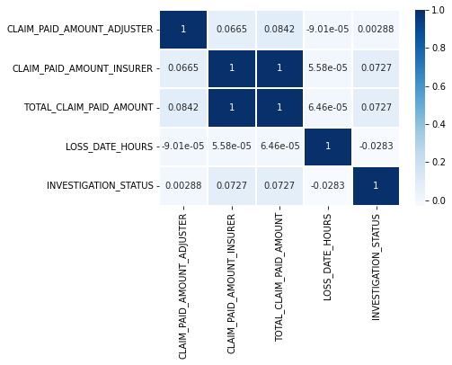

```python
plt.figure()
sns.heatmap(hist_claims.corr(),cmap='Blues', fmt='.3g',linewidths=0.30,annot=True)
plt.show()
```

#### Aim : Calculation of Incurred Claim Ratio

```python
total_premium_collected = policies['GWP'].sum()
```

```python
total_claim_paid = hist_claims['TOTAL_CLAIM_PAID_AMOUNT'].sum()
```

```python
total_claim_paid / total_premium_collected
```

```
0.171557546744118
```

#### Conclusion: ICR indicates Client X's ability to pay incurring claims. For every 1 currency value collected company pays only 0.17 currency value

#### Aim : Top 5 and Bottom 5 States where a particular incident has occured.

```python
hist_claims['LOSS_STATE'].value_counts().head(5)
```

```
STATE_1     75284
STATE_4     59643
STATE_9     44844
STATE_5     40958
STATE_10    40646
Name: LOSS_STATE, dtype: int64
```

```python
hist_claims['LOSS_STATE'].value_counts().tail(5)
```

```
STATE_28    5142
STATE_21    1664
STATE_29    1647
STATE_26     641
STATE_3      488
Name: LOSS_STATE, dtype: int64
```

#### Conclusion: Client X can hence introduce a " Pay as You Drive Plan" . If an insured is a frequent driver in top 5 states that are prone to incidents , then they may be charged higher premiums and vice-versa for the bottom 5 states

```python
pd.crosstab(hist_claims['LOSS_STATE'],hist_claims['EVENT_TYPE']).idxmax(axis=0)
```

```
EVENT_TYPE
COLLISION                                            STATE_1
COLLISION PERSONAL ACCIDENT                          STATE_1
COLLISION THIRD PARTY INVOLVEMENT                    STATE_1
COLLISION THIRD PARTY INVOLVEMENT PROPERTY DAMAGE    STATE_1
EARTHQUAKE/LANDSLIDE                                 STATE_1
FIRE                                                 STATE_1
FLOOD/CYCLONE                                        STATE_1
IMPACT                                               STATE_1
MALICIOUS DAMAGE                                     STATE_1
THEFT                                                STATE_1
dtype: object
```

#### State 1 tops every state when looking at the total number of incidents.

Aim : Top 5 and Bottom 5 Cities from where maximum and minimum number of claims have been processed .

```python
hist_claims['CLAIM_PROCESSING_LOCATION'].value_counts().head(5)
```

```
CITY_22    19490
CITY_55    19092
CITY_11    18701
CITY_8     18401
CITY_9     17132
Name: CLAIM_PROCESSING_LOCATION, dtype: int64
```

```python
hist_claims['CLAIM_PROCESSING_LOCATION'].value_counts().tail(5)
```

```
CITY_103    374
CITY_102    268
CITY_101     88
CITY_91      79
CITY_106     63
Name: CLAIM_PROCESSING_LOCATION, dtype: int64
```

#### Conclusion: Client X has varied processing locations . Some cities have been outstripping the total processing burden . As a result Client X can look to channelize its operations and streamline them to increase operational efficiency and optimal load balancing

#### Aim : Contribution of Event Type

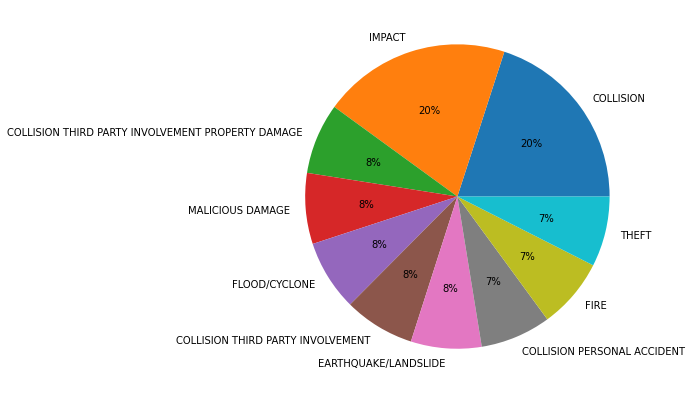

```python
hist_claims['EVENT_TYPE'].value_counts().plot(kind='pie',figsize =(10, 7), autopct='%1.0f%%')
plt.ylabel("")
```

#### Conclusion: Collision and Impact are the most frequent type of Events for which the claims have been filed

#### Feature Engineering of the Event Type column

```python
def set_scr3(hist_claims):
    if hist_claims['EVENT_TYPE'] in ('FLOOD/CYCLONE' , 'EARTHQUAKE/LANDSLIDE'):
        return 'Natural_Hazards'
    if hist_claims['EVENT_TYPE'] == 'FIRE':
        return 'Fire'
    if hist_claims['EVENT_TYPE'] == 'MALICIOUS DAMAGE':
        return 'Intentional_Damage'
    if hist_claims['EVENT_TYPE'] == 'THEFT ':
        return 'Theft'
    else :
        return 'Collision'
```

```python
hist_claims['Pooled_Event_Type'] = hist_claims.apply(set_scr3,axis=1)
```

```python
hist_claims['Pooled_Event_Type'].value_counts()
```

[output not shown]

#### Aim : Analyse Claim Status Variable

```python
hist_claims['CLAIM_STATUS'].value_counts(normalize=True)*100.0
```

```
CLOSED    96.465067
REOPEN     3.050847
OPEN       0.484086
Name: CLAIM_STATUS, dtype: float64
```

#### Conclusion: Client X has been successful in closing 96% of the Total Claims . Furthermore, 3% of the claims have been reopened . SInce there are values such as Reopen and Open , we can further investigate this and lookup the Claim Close Date Column.

```python
hist_claims[hist_claims['CLAIM_CLOSED_DATE'].isna()]['CLAIM_STATUS'].value_counts()
```

```
REOPEN    19827
OPEN       3146
Name: CLAIM_STATUS, dtype: int64
```

#### Conclusion: As expected, there are 2 reasons behind claim close date to go missing . Either the claim is still in process ( open ) or the claim has been reopened

#### Aim : Analyse Claim Assessors Variable

```python
hist_claims['CLAIM_ASSESSORS'].value_counts().head()
```

```
HANDLER_160    2279
HANDLER_250    2274
HANDLER_284    2267
HANDLER_98     2259
HANDLER_13     2258
Name: CLAIM_ASSESSORS, dtype: int64
```

#### Conclusion: Client X has 300 Claim Assessor. Each assessor has been equally tasked.

#### Aim : Analyse the Total Claim Amount Paid to Insured.

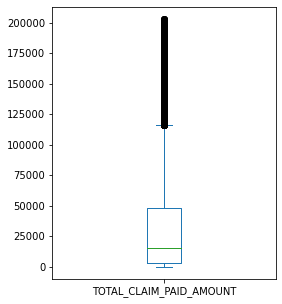

```python
hist_claims['TOTAL_CLAIM_PAID_AMOUNT'].plot(kind='box',figsize =(4, 5))
```

#### Conclusion: Many claims are being settled for a Large Sum of Value

#### Aim : Incidents varying according to Loss Date Hours

```python
hist_claims['LOSS_DATE_HOURS'].value_counts().head(5)
```

```
0     129894
21     22900
9      22794
18     22761
17     22760
Name: LOSS_DATE_HOURS, dtype: int64
```

#### Conclusion: Maximum incidents occour at Hour 0 ( Midnight) .

### Feature Engineering on Claims Data

#### Aim : How long it takes for :

- A claim to be notified to the insurer ?
- A claim to be setlled after being notified to the insurer ?
- A Claim to be settled since the Loss Date ?

```python
hist_claims['DATE_OF_LOSS'] = pd.to_datetime(hist_claims['DATE_OF_LOSS'])
hist_claims['NOTIFICATION_DATE'] = pd.to_datetime(hist_claims['NOTIFICATION_DATE'])
hist_claims['CLAIM_CLOSED_DATE'] = pd.to_datetime(hist_claims['CLAIM_CLOSED_DATE'])
hist_claims['REOPEN_DATE'] = pd.to_datetime(hist_claims['REOPEN_DATE'])
```

```python
hist_claims['Loss_To_Notification_Days'] = pd.to_datetime(hist_claims['NOTIFICATION_DATE']) - pd.to_datetime(hist_claims['DATE_OF_LOSS'])
```

```python
hist_claims['Notification_To_ClaimCls_Days'] =hist_claims['CLAIM_CLOSED_DATE'] -hist_claims['NOTIFICATION_DATE']
hist_claims['Total_days_to_settle'] = hist_claims['Loss_To_Notification_Days'] + hist_claims['Notification_To_ClaimCls_Days']
```

```python
hist_claims[['Loss_To_Notification_Days','Notification_To_ClaimCls_Days','Total_days_to_settle']].head()
```

|  | Loss_To_Notification_Days | Notification_To_ClaimCls_Days | Total_days_to_settle |
| --- | --- | --- | --- |
| 0 | 4 days | 61 days | 65 days |
| 1 | 25 days | 45 days | 70 days |
| 2 | 19 days | 52 days | 71 days |
| 3 | 29 days | 33 days | 62 days |
| 4 | 8 days | 73 days | 81 days |

```python
hist_claims['Loss_To_Notification_Days'].mean()
```

```
Timedelta('15 days 00:22:40.841379628')
```

```python
hist_claims['Notification_To_ClaimCls_Days'].mean()
```

```
Timedelta('54 days 10:30:10.336378948')
```

```python
hist_claims['Total_days_to_settle'].mean()
```

```
Timedelta('69 days 10:55:50.870297583')
```

#### Conclusion:

- A customer on an average takes 15 days to notify the loss to the insurer
- Client X on an average takes 54 days to settle the claim once notified by the insured
- Client X on an average takes 69 days to complete the entire insurance claim cycle

```python
policies_new = policies.drop(columns=['PREVIOUS_INSURER_NAME','PRODUCT_CODE'])
hist_claims_new = hist_claims.drop(columns=['DATE_OF_SUVERY_APPOINTMENT','CLAIM_PROCESSING_LOCATION','DATE_OF_SURVEY','DOCUMENT_RECEIVED_DATE','REPAIR_APPROVAL_DATE','INVOICE_DATE','APPROVED_DATE_INSURER','PAYMENT_CREATION_DATE_INSURER','APPROVED_DATE_ADJUSTER','PAYMENT_CREATION_DATE_ADJUSTER','INSURER_CLOSED_DATE','EXPENSE_CLOSED_DATE','CLAIM_ASSESSORS', 'WORKSHOP_IDENTIFIER','REOPEN_STATUS','REOPEN_DATE'])
```

# Merging the 3 Datasets

```python
hist_pol = pd.merge(policies_new,hist_claims_new,how='inner',on='POLICY_IDENTIFIER')
hist_pol.shape
```

```
(649885, 31)
```

```python
df = pd.merge(hist_pol,customer,how='inner',on='CUSTOMER_IDENTIFIER')
df.shape
```

```
(649885, 33)
```

```python
print('Client X has,',len(df['CUSTOMER_IDENTIFIER'].unique()),'unique customers who have purchased policies and have also claimed')
```

```
Client X has, 412603 unique customers who have purchased policies and have also claimed
```

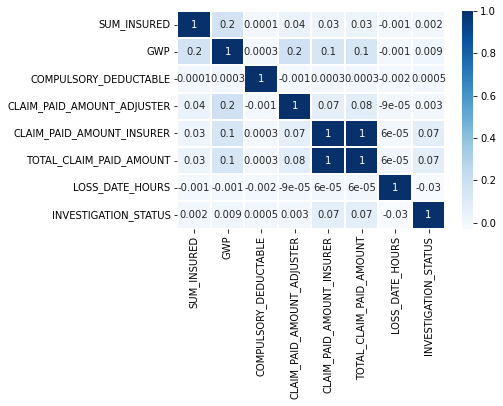

```python
plt.figure()
sns.heatmap(df.corr(),cmap='Blues', fmt='.01g',linewidths=0.30,annot=True)
plt.show()
```

#### Aim: Find out customers the customers claiming multiple times

```python
df['CUSTOMER_IDENTIFIER'].value_counts()
```

```
CUSTOMER_705545    12
CUSTOMER_376343    10
CUSTOMER_997996    10
CUSTOMER_186031    10
CUSTOMER_656337    10
                   ..
CUSTOMER_464229     1
CUSTOMER_183476     1
CUSTOMER_333108     1
CUSTOMER_526222     1
CUSTOMER_558929     1
Name: CUSTOMER_IDENTIFIER, Length: 412603, dtype: int64
```

#### A customer is claiming 12 times ? Is it on the backs of multiple policies purchased ( 12 ) ? Or is it that 1 policy is being claimed 12 Times ? Let's find this out using a Ratio Called Risk Factor

### Building a Customer Centric Data

```python
X = df.groupby('CUSTOMER_IDENTIFIER')['POLICY_IDENTIFIER'].nunique()
Y = df.groupby('CUSTOMER_IDENTIFIER')['CLAIM_IDENTIFIER'].nunique()
Z = df.groupby('CUSTOMER_IDENTIFIER')['GENDER'].max()
A = df.groupby('CUSTOMER_IDENTIFIER')['DRIVING_EXPERIENCE'].max()
B = df.groupby('CUSTOMER_IDENTIFIER')['GWP'].sum()
C = df.groupby('CUSTOMER_IDENTIFIER')['TOTAL_CLAIM_PAID_AMOUNT'].sum()
D = df.groupby('CUSTOMER_IDENTIFIER')['Total_days_to_settle'].mean()
```

```python
X_1 = pd.merge(X,Y,how='inner',left_index=True,right_index=True)
X_1 = pd.merge(X_1,Z,how='inner',left_index=True,right_index=True)
X_1 = pd.merge(X_1,A,how='inner',left_index=True,right_index=True)
X_1 = pd.merge(X_1,B,how='inner',left_index=True,right_index=True)
X_1 = pd.merge(X_1,C,how='inner',left_index=True,right_index=True)
X_1 = pd.merge(X_1,D,how='inner',left_index=True,right_index=True)
```

```python
X_1.head()
```

| CUSTOMER_IDENTIFIER | POLICY_IDENTIFIER | CLAIM_IDENTIFIER | GENDER | DRIVING_EXPERIENCE | GWP | TOTAL_CLAIM_PAID_AMOUNT | Total_days_to_settle |
| --- | --- | --- | --- | --- | --- | --- | --- |
| CUSTOMER_1 | 1 | 1 | M | THREE_TO_FIVE_YEARS | 80815 | 20318 | 39 days 00:00:00 |
| CUSTOMER_10 | 1 | 1 | M | THREE_TO_FIVE_YEARS | 87466 | 4708 | 81 days 00:00:00 |
| CUSTOMER_10000 | 1 | 1 | F | THREE_TO_FIVE_YEARS | 61114 | 32397 | 63 days 00:00:00 |
| CUSTOMER_100000 | 2 | 2 | M | THREE_TO_FIVE_YEARS | 150709 | 60644 | 58 days 00:00:00 |
| CUSTOMER_1000003 | 3 | 3 | M | THREE_TO_FIVE_YEARS | 79955 | 361416 | 123 days 16:00:00 |

```python
X_1['RiskFactor'] = X_1['CLAIM_IDENTIFIER']/X_1['POLICY_IDENTIFIER']
X_1['RiskFactor'] = X_1['RiskFactor'].round(0)
X_1.rename(columns={'POLICY_IDENTIFIER':'Total_Policies','CLAIM_IDENTIFIER':'Total_Claims'},inplace=True)
```

#### Risk Factor takes the value between 1 to 5

- 1 implies the least Risky customer
- 5 implies the most Risky customer

```python
X_1.groupby('RiskFactor')['GWP'].mean()
```

```
RiskFactor
1.0     64520.800084
2.0    113143.969306
3.0    130119.641651
4.0    161926.000000
5.0    197882.000000
Name: GWP, dtype: float64
```

```python
X_1.groupby('RiskFactor')['TOTAL_CLAIM_PAID_AMOUNT'].mean()
```

```
RiskFactor
1.0     58361.447461
2.0    102420.149013
3.0    117879.918074
4.0    166211.017857
5.0    130343.200000
Name: TOTAL_CLAIM_PAID_AMOUNT, dtype: float64
```

#### Conclusion: If the Risk Factor is 1 then the number of policies purchased is equal to the number of claims . If the number of policies purchased is less than the number of claims for a customer then the risk factor associated with that customer will increase and that explains the higher GWP

#### Aim : Find the least profitable product in Client X's portfolio

```python
Premium_by_product = policies.groupby('PRODUCT')['GWP'].mean()
```

```python
Premium_by_product
```

```
PRODUCT
COMMERCIAL MOTOR GOODS CARRYING            47153.672004
COMMERCIAL MOTOR MISCELLANEOUS VEHICLES    43160.258110
COMMERCIAL MOTOR PASSENGER CARRYING        48124.660620
LONG TERM TWO WHEELER PACKAGE              39334.134554
MOTOR TRADE INSURANCE                      39389.948621
PRIVATE MOTOR 2 WHEELER                    39382.583990
PRIVATE MOTOR 3 & 4 WHEELER                48036.332703
Name: GWP, dtype: float64
```

```python
Claims_by_product = df.groupby('PRODUCT')['TOTAL_CLAIM_PAID_AMOUNT'].mean()
```

```python
Claims_by_product
```

```
PRODUCT
COMMERCIAL MOTOR GOODS CARRYING            48892.816003
COMMERCIAL MOTOR MISCELLANEOUS VEHICLES    48752.428005
COMMERCIAL MOTOR PASSENGER CARRYING        49017.800503
LONG TERM TWO WHEELER PACKAGE              23443.521333
MOTOR TRADE INSURANCE                      23740.855778
PRIVATE MOTOR 2 WHEELER                    23535.523088
PRIVATE MOTOR 3 & 4 WHEELER                49067.545788
Name: TOTAL_CLAIM_PAID_AMOUNT, dtype: float64
```

```python
(Premium_by_product - Claims_by_product).sort_values()
```

```
PRODUCT
COMMERCIAL MOTOR MISCELLANEOUS VEHICLES    -5592.169895
COMMERCIAL MOTOR GOODS CARRYING            -1739.143998
PRIVATE MOTOR 3 & 4 WHEELER                -1031.213086
COMMERCIAL MOTOR PASSENGER CARRYING         -893.139883
MOTOR TRADE INSURANCE                      15649.092844
PRIVATE MOTOR 2 WHEELER                    15847.060902
LONG TERM TWO WHEELER PACKAGE              15890.613221
dtype: float64
```

- Commercial segment looks to be a cash burning vertical since premium collected is less than claim amount incurred

#### Aim : Event and Product Type

```python
pd.crosstab(df['EVENT_TYPE'],df['PRODUCT']).idxmax(axis=1)
```

```
EVENT_TYPE
COLLISION                                            PRIVATE MOTOR 3 & 4 WHEELER
COLLISION PERSONAL ACCIDENT                          PRIVATE MOTOR 3 & 4 WHEELER
COLLISION THIRD PARTY INVOLVEMENT                    PRIVATE MOTOR 3 & 4 WHEELER
COLLISION THIRD PARTY INVOLVEMENT PROPERTY DAMAGE    PRIVATE MOTOR 3 & 4 WHEELER
EARTHQUAKE/LANDSLIDE                                 PRIVATE MOTOR 3 & 4 WHEELER
FIRE                                                 PRIVATE MOTOR 3 & 4 WHEELER
FLOOD/CYCLONE                                        PRIVATE MOTOR 3 & 4 WHEELER
IMPACT                                               PRIVATE MOTOR 3 & 4 WHEELER
MALICIOUS DAMAGE                                     PRIVATE MOTOR 3 & 4 WHEELER
THEFT                                                PRIVATE MOTOR 3 & 4 WHEELER
dtype: object
```

#### Conclusion: Be it any event , most number of claims are from Private Motor 3 & 4 Wheeler . Client X can therefore reduce its exposure to this segment of Motor Insurance

#### Aim : Maximum number of days taken to settle a claim

```python
df[df['Total_days_to_settle'].sort_values(ascending=False) > '364 days'].head()
```

[output not shown]

```python
len(df[df['Total_days_to_settle'].sort_values(ascending=False) > '364 days'])
```

```
3043
```

#### Conclusion: More than 3000 claims have been settled after 364 days ( 1 year ) . Client X should investigate this because ignoring the same shall put the reputation of the client at risk leading to unsatisfied customers and greater customer churn

#### By :- Arham Lodha